# 8 Convolutional Neural Networks

**Key references**

- **LeNet** — the first successful convolutional neural network for image recognition (LeCun et al., 1989).
- **AlexNet** — deep CNN that won the ImageNet competition and launched the deep-learning era (Krizhevsky et al., 2012).
- **U-Net** — encoder-decoder architecture with skip connections for dense prediction (Ronneberger et al., 2015).
- **ResNet** — residual connections enabling very deep networks (100+ layers) (He et al., 2016).

A **convolutional neural network** (CNN) exploits the spatial structure in data — the fact that nearby pixels or grid cells tend to be related. Instead of connecting every input to every neuron, a CNN slides small learned filters across the data, detecting local patterns such as edges, textures, and shapes. This makes CNNs far more parameter-efficient than feedforward networks for image-like data, and it gives them a property fully-connected networks lack: **translation equivariance** — the same pattern is recognised wherever it appears in the image, because the same filter is applied at every location.

## 8.1 The convolution operation

In a CNN, a **filter** (or **kernel**) is a small set of weights: a short vector for 1D traces, or a small matrix such as $3 \times 3$ or $5 \times 5$ for 2D images. The filter slides across the input and at each position computes a dot product between the filter weights and the local patch of input values. This produces a **feature map** — a new grid where each cell represents how strongly that local pattern was detected at that position.

For a 2D input $\mathbf{X}$ and a filter $\mathbf{K}$ of size $k \times k$, the convolution at position $(i, j)$ is:

$$(\mathbf{X} * \mathbf{K})_{i,j} = \sum_{m=0}^{k-1} \sum_{n=0}^{k-1} \mathbf{K}_{m,n} \cdot \mathbf{X}_{i+m,\, j+n}$$

A convolutional layer applies many such filters in parallel, each learning to detect a different pattern.

For a 1D trace, the same operation uses one spatial index instead of two:

$$(\mathbf{x} * \mathbf{k})_i = \sum_{m=0}^{k-1} \mathbf{k}_m \cdot \mathbf{x}_{i+m}$$

## 8.2 Pooling

After convolution, **pooling** layers reduce the spatial size of the feature maps, keeping only the most important information. The most common type is **max pooling**, which takes the maximum value in each small window (e.g., length 2 for traces or $2 \times 2$ for images). Pooling reduces computation, provides some translation invariance, and increases the receptive field of deeper layers.

## 8.3 Two CNN templates

CNNs come in two main shapes, depending on what the output should look like:

- **Classifier (LeNet/AlexNet-style)** — alternates convolution and pooling, then flattens to dense layers that produce a fixed-size class vector. Good for “what is in this image” questions.
- **Encoder–decoder (U-Net-style)** — downsamples to a low-resolution feature map, then upsamples back to the original resolution with transposed convolutions, producing one prediction *per pixel*. Good for “where in this image” questions: segmentation, denoising, super-resolution.

Geophysics uses both templates. Dense predictors are common for faults, salt bodies, and horizons; classifiers are useful when the question is whether a short window contains a particular waveform or structure. The worked example below uses the classifier template because it is small enough to run comfortably on a CPU.

## 8.4 Code example: classifying synthetic seismic traces

We train a compact 1D CNN to classify short synthetic seismic traces into three classes: quiet background, a positive-polarity arrival, and a negative-polarity arrival. The arrival position is random, so the network must recognise the waveform regardless of where it appears in the trace.

This problem is a CNN’s natural habitat:

- The arrival can sit anywhere in the trace, so we need the same detector applied at every sample -> **parameter sharing**.
- The class depends on a *local waveform shape* rather than on one fixed sample location -> **local receptive fields**.
- A 1D trace keeps the example small while showing the same convolutional idea used by larger 2D and 3D CNNs.

```julia
using Lux, Random, Optimisers, Zygote, Statistics, Printf, CairoMakie

rng = Xoshiro(42)
n = 64
class_names = ["Quiet", "Positive arrival", "Negative arrival"]
```

```
3-element Vector{String}:
 "Quiet"
 "Positive arrival"
 "Negative arrival"
```

```julia
# Generate one labelled synthetic seismic trace.
function make_trace_example(rng, n = n; class_id = rand(rng, 1:3))
    samples = Float32.(1:n)
    t = Float32.(range(0, 1, length = n))

    phase = rand(rng, Float32)
    trace = 0.03f0 .* randn(rng, Float32, n)
    trace .+= 0.04f0 .* sin.(2f0 * Float32(pi) .* (2.5f0 .* t .+ phase))

    if class_id != 1
        center = rand(rng, 12:n-12)
        width = 2.6f0 + 0.8f0 * rand(rng, Float32)
        polarity = class_id == 2 ? 1f0 : -1f0
        d = (samples .- center) ./ width
        wavelet = exp.(-0.5f0 .* d .^ 2)
        trace .+= polarity .* (0.90f0 + 0.10f0 * rand(rng, Float32)) .* wavelet
    end

    trace .-= mean(trace)
    trace = clamp.(trace, -1f0, 1f0)

    y = zeros(Float32, 3)
    y[class_id] = 1f0
    return reshape(trace, n, 1), y, class_id
end

n_samples = 180
X = zeros(Float32, n, 1, n_samples)    # (samples, channels, batch)
Y = zeros(Float32, 3, n_samples)
for i in 1:n_samples
    trace, y, _ = make_trace_example(rng; class_id = mod1(i, 3))
    X[:, :, i] = trace
    Y[:, i] = y
end

idx     = randperm(rng, n_samples)
n_train = round(Int, 0.80 * n_samples)
tr      = idx[1:n_train]
te      = idx[n_train+1:end]

X_train, Y_train = X[:, :, tr], Y[:, tr]
X_test,  Y_test  = X[:, :, te], Y[:, te]
```

[output not shown]

The input tensor has shape `(samples, channels, batch)`, and the label for each trace is a one-hot vector with three entries.

```julia
# Small 1D CNN classifier.
model = Chain(
    Conv((5,), 1 => 8, relu; pad = SamePad()),
    MaxPool((2,)),                                # 32 samples
    WrappedFunction(x -> reshape(x, :, size(x, 3))),
    Dense(8 * 32 => 16, relu),
    Dense(16 => 3),
)

ps, st = Lux.setup(rng, model)

function softmax_cols(x)
    x_shift = x .- maximum(x, dims = 1)
    ex = exp.(x_shift)
    ex ./ sum(ex, dims = 1)
end

function cross_entropy_loss(model, ps, st, data)
    x, y = data
    logits, st_new = model(x, ps, st)
    prob = softmax_cols(logits)
    loss = -mean(sum(y .* log.(prob .+ 1f-7), dims = 1))
    return loss, st_new, ()
end

function predicted_classes(probabilities)
    [findmax(probabilities[:, i])[2] for i in axes(probabilities, 2)]
end

function true_classes(labels)
    [findmax(labels[:, i])[2] for i in axes(labels, 2)]
end
```

```
true_classes (generic function with 1 method)
```

```julia
function train_classifier(model, ps, st, data; epochs = 60, lr = 5f-3)
    tstate = Training.TrainState(model, ps, st, Adam(lr))
    for epoch in 1:epochs
        _, loss, _, tstate = Training.single_train_step!(
            AutoZygote(), cross_entropy_loss, data, tstate
        )
        if epoch == 1 || epoch % 15 == 0
            @printf "Epoch %2d  cross-entropy = %.4f\n" epoch loss
        end
    end
    return tstate
end

tstate = train_classifier(model, ps, st, (X_train, Y_train))
```

```
Epoch  1  cross-entropy = 1.1431
Epoch 15  cross-entropy = 0.2116
Epoch 30  cross-entropy = 0.0077
Epoch 45  cross-entropy = 0.0013
Epoch 60  cross-entropy = 0.0007
```

```
TrainState(
    Chain(
        layer_1 = Conv((5,), 1 => 8, relu, pad=2),  # 48 parameters
        layer_2 = MaxPool((2,)),
        layer_3 = WrappedFunction(#3),
        layer_4 = Dense(256 => 16, relu),         # 4_112 parameters
        layer_5 = Dense(16 => 3),                 # 51 parameters
    ),
    number of parameters: 4211
    number of states: 0
    optimizer: Adam(eta=0.005, beta=(0.9, 0.999), epsilon=1.0e-8)
    step: 60
)
```

```julia
test_logits, _ = model(X_test, tstate.parameters, tstate.states)
test_prob = softmax_cols(test_logits)
test_loss = -mean(sum(Y_test .* log.(test_prob .+ 1f-7), dims = 1))
test_acc = mean(predicted_classes(test_prob) .== true_classes(Y_test))
@printf "Holdout cross-entropy: %.4f  Accuracy: %.3f\n" test_loss test_acc

for i in 1:3
    class_idx = true_classes(Y_test) .== i
    class_acc = mean(predicted_classes(test_prob)[class_idx] .== i)
    @printf "%s accuracy: %.3f\n" class_names[i] class_acc
end
```

```
Holdout cross-entropy: 0.0008  Accuracy: 1.000
Quiet accuracy: 1.000
Positive arrival accuracy: 1.000
Negative arrival accuracy: 1.000
```

The holdout accuracy checks whether the CNN learned a location-independent waveform detector rather than memorising a fixed arrival sample.

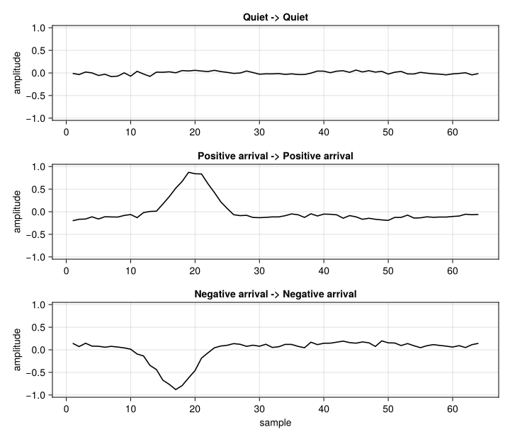

```julia
function sample_with_label(seed, wanted_label)
    rng_local = Xoshiro(seed)
    while true
        x, y, class_id = make_trace_example(rng_local)
        class_id == wanted_label && return x, y, class_id
    end
end

examples = [sample_with_label(100 + 17i, i) for i in 1:3]
fig = Figure(size = (720, 620))

for (row, (trace, _, class_id)) in enumerate(examples)
    logits, _ = model(reshape(trace, n, 1, 1), tstate.parameters, tstate.states)
    prob = softmax_cols(logits)
    predicted = findmax(prob[:, 1])[2]

    ax = Axis(fig[row, 1],
              title = "$(class_names[class_id]) -> $(class_names[predicted])",
              xlabel = row == 3 ? "sample" : "",
              ylabel = "amplitude")
    lines!(ax, 1:n, trace[:, 1]; color = :black, linewidth = 1.6)
    ylims!(ax, -1.05, 1.05)
end
fig
```

The final plot shows one trace from each class. The title reports the true class followed by the predicted class, giving a direct visual check of the trained 1D CNN.

## 8.5 Key CNN architectures

Several landmark architectures expanded the capabilities of CNNs:

- **ResNet** (He et al., 2016) — introduces skip connections that add the input of a block to its output, enabling training of very deep networks (100+ layers) without vanishing gradients.
- **U-Net** (Ronneberger et al., 2015) — an encoder-decoder architecture with skip connections at each resolution level, originally designed for biomedical image segmentation. Production geoscience U-Nets use this downsample-then-upsample template for dense prediction tasks such as fault or salt segmentation.

## 8.6 Geoscience milestones

- **3D seismic fault segmentation** — Wu et al. (2019) (FaultSeg3D) trained a 3D CNN on synthetic seismic volumes to segment faults directly from amplitude data, and remains the canonical reference for CNN-based fault interpretation.
- **Earthquake detection from raw waveforms** — Perol et al. (2018) (ConvQuake) showed that a 1D CNN can detect and locate earthquakes directly from seismograms, establishing the translation-equivariant view of seismic detection.

The key insight is: **whenever your geoscience data lives on a regular grid and the relevant pattern can appear anywhere, a CNN is likely a good starting point**. The spatial weight sharing built into convolutions matches the physics of spatially correlated earth properties and the way features such as faults, salt edges, or channel boundaries are defined locally rather than globally.

He, K., Zhang, X., Ren, S., & Sun, J. (2016). Deep residual learning for image recognition. *Proceedings of the IEEE Conference on Computer Vision and Pattern Recognition (CVPR)*, 770–778. https://doi.org/10.1109/CVPR.2016.90

Krizhevsky, A., Sutskever, I., & Hinton, G. E. (2012). ImageNet classification with deep convolutional neural networks. *Advances in Neural Information Processing Systems*, *25*.

LeCun, Y., Boser, B., Denker, J. S., Henderson, D., Howard, R. E., Hubbard, W., & Jackel, L. D. (1989). Backpropagation applied to handwritten zip code recognition. *Neural Computation*, *1*(4), 541–551. https://doi.org/10.1162/neco.1989.1.4.541

Perol, T., Gharbi, M., & Denolle, M. (2018). Convolutional neural network for earthquake detection and location. *Science Advances*, *4*(2), e1700578. https://doi.org/10.1126/sciadv.1700578

Ronneberger, O., Fischer, P., & Brox, T. (2015). U-net: Convolutional networks for biomedical image segmentation. *Medical Image Computing and Computer-Assisted Intervention (MICCAI)*, 234–241. https://doi.org/10.1007/978-3-319-24574-4_28

Wu, X., Liang, L., Shi, Y., & Fomel, S. (2019). FaultSeg3D: Using synthetic data sets to train an end-to-end convolutional neural network for 3D seismic fault segmentation. *Geophysics*, *84*(3), IM35–IM45. https://doi.org/10.1190/geo2018-0646.1